# Unit 2 - Working with Vector Data

Lyndon Estes, Zhiwen Zhu

2017-11-04

# 1 Introduction

In this section we are going to use R to work with vector data, learning the most common forms of spatial operations that work with vector data. This means we will be working primarily with the following packages: `sp`, `rgdal`, and `rgeos`. We **might** touch on, towards the end, the new `sf` package, which is new but already more powerful than `sp`, which it is designed to replace. Okay, so why are we learning about `sp`? Please ask me about that in class!

> The material in this section assumes that the reader is familiar with standard GIS operations and concepts, ranging from projections and transformations to intersections, buffers, and differencing. It also assumes that you have already read Chapter 2 in *Applied Spatial Data Analysis with R* (ASDAR), and know the basics of R spatial classes.

> The reading is designed with the expectation that you work through the code as you read through it. It mixes code and explanation of the code with some exercises to practice on your own. Additionally, you should also look at the help file for each new function that is introduced, in order to familiarize yourself with the arguments.

Back to top

# 2 Preparation

## 2.1 Working space

We present here a mix of explanation with code and exercises to help you learn it. We recommend that you work through these readings as follows:

1. Create a new folder under your favorite installation directory. Call it `unit2` os something similar. Make two sub-folders underneath that, one called `data`, the other `scratch`.
2. Under the `scratch` folder, create a new script file called “readings.R”. The first line of this should call `library(geospaar)`. Below this, you can paste in and work through the code provided by the reading, including any code we ask you to create as part of the in-reading exercises.
3. Read and write any data we ask you to create as part of the exercises to the “data” folder.
4. Before each reading, remember to reinstall `geospaar` to get the latest version.

## 2.2 Installations

Let’s start by loading the following packages.

```r
library(geospaar)
library(sp)
library(rgdal)
```

`sp` you should already know about from your ASDAR reading. `rgdal` is something you probably haven’t looked into much yet, so what is it? This is a package that, according to `rgdal`’s DESCRIPTION file:

```
Provides bindings to the Geospatial Data Abstraction Library ('GDAL') (>= 1.6.3) and access to projection/transformation operations from the 'PROJ.4' library. The 'GDAL' and 'PROJ.4' libraries are external to the package, and, when installing the package from source, must be correctly installed first. Both 'GDAL' raster and 'OGR' vector map data can be imported into R, and 'GDAL' raster data and 'OGR' vector data exported.
```

That means that `rgdal` allows us to call these external libraries that give us the ability to read in a wide range of raster and vector formats, provided we have these libraries already installed on our computer.

So, you probably have to install these first. Platform specific instructions follow.

### 2.2.1 Windows

You should be able to do most of the work in this section by simply installing the `rgdal` library.

### 2.2.2 Mac

The same holds as for Windows (just install `rgdal`), but you might also have to install the full GDAL and PROJ.4 libraries. The easiest way to do that is to go to William Kyngesburye’s website to [download the latest QGIS version](http://www.kyngchaos.com/software/qgis), which as of writing (9 October, 2017) is 2.18.13-1. The installer bundles in GDAL and PROJ.4 along with QGIS, doing it all for you in one go. Read the page first and then the various readme’s accompanying the install files you extract from the .dmg.

Back to top

# 3 Section 1

This reading introduces reading, writing, and making vector data, how to work with their coordinate reference systems (crs), and how to do some basic plotting, leavened with some additional R programming examples. There are 5 self-examination exercises interspersed throughout the text. You can jump to them from here:

## 3.1 Exercises

- Exercise #1
- Exercise #2
- Exercise #3
- Exercise #4
- Exercise #5

## 3.2 Reading, writing, and making vector data

### 3.2.1 From non-spatial to `SpatialPoints`

We are going to start by reading in another permutation of the farmer dataset that you were working with in Unit 1, but this time it comes with spatial data attached. These data ship with `geospaar` version 0.3.5+, and are currently in .csv format.

```r
farmers <- read.csv(system.file("extdata/farmer_spatial.csv",
                                package = "geospaar"), stringsAsFactors = FALSE)
head(farmers)
```

```
##       uuid      lat     lon       date pl ra
## 1 009a8424 -16.9257 27.2559 2016-10-31 NA  0
## 2 00df166f -16.5036 26.9425 2016-10-31 NA  0
## 3 019d99f9 -13.1991 24.7820 2016-10-31 NA  0
## 4 02671a00 -16.9137 27.2537 2016-10-31 NA  0
## 5 02be9843 -15.4070 27.0849 2016-10-31 NA  0
## 6 0360d642 -16.6044 26.8255 2016-10-31 NA  0
```

Okay, so this looks similar to what we had before, but now we have a “lat” and a “lon” column, and are also missing the “mm” column. First, check the class of the `farmers`. It will show you that it is a `data.frame`, which means it is non-spatial at the moment. But we can see that we have some coordinates there, and they are in decimal degree format. Given that these are point data, we can turn them into a facsimile of spatial data by simply plotting them and having a look.

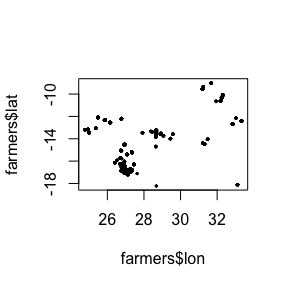

```r
plot(x = farmers$lon, y = farmers$lat, pch = 20, cex = 0.5)
```

So that shows you, in a very crude way, where these points lie in space, given that `farmers$lon` (the longitude) is exactly analogous to the x coordinate of a scatter plot, and `farmers$lat` (latitude) is the y coordinate. But it is still not a spatial object. So, let’s convert it to one, and then plot it again.

```r
coordinates(farmers) <- ~lon + lat
head(farmers)
```

```
## class       : SpatialPointsDataFrame
## features    : 6
## extent      : 24.782, 27.2559, -16.9257, -13.1991  (xmin, xmax, ymin, ymax)
## coord. ref. : NA
## variables   : 4
## names       :     uuid,       date, pl, ra
## min values  : 009a8424, 2016-10-31, NA,  0
## max values  : 0360d642, 2016-10-31, NA,  0
```

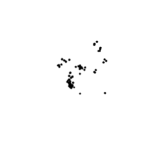

```r
plot(farmers, pch = 20, cex = 0.5)
```

Now, a few things about the code above and results above. *First*, if you compare the result of `head (farmers)` to the previous version, you will see the “lat” and “lon” columns have disappeared and are replaced by the “coordinates” column. *Next*, notice how `plot` is used. It applies to the entire object `farmers`, and the output plot looks somewhat different than the previous version. This is the result of having promoted `farmers` from a `data.frame` to a spatial object, and the plot function operates differently on a spatial object than it does for ordinary vectors. *Third*, the promotion was accomplished by the first line of code in the block above. There are a few things about that line that might seem curious: the “~” and the lack of quotes around the column names on the right hand side of the operator (`<-`); the function being applied to an object on the left hand side of the assignment operator (`coordinates(farmers)`). You have seen the latter aspect before in Unit 1, but we never really talked about it (for example, when changing a `data.frame`’s column names: `colnames(dat) <- c("a", "b")`). Suffice to say, this sort of syntax means you are modifying the properties of an existing object (in this case, we are changing a `data.frame` into something spatial).

Now, what sort of spatial object is `farmers` after this promotion?

```r
class(farmers)
```

```
## [1] "SpatialPointsDataFrame"
## attr(,"package")
## [1] "sp"
```

Gives the answer. We can *coerce*, or demote, `farmers` back to an ordinary `data.frame` by simply doing this:

```r
farmers <- as.data.frame(farmers)
class(farmers)
```

```
## [1] "data.frame"
```

We can also simply convert `farmers` coordinates to `SpatialPoints`, a simpler spatial class that lacks the accompanying `data.frame`. We are not going to show that here, because that is your first exercise to complete

Exercise 1: *Figure out how to convert `farmers` to just `SpatialPoints`, rather than a `SpatialPointsDataFrame`* (Exercise index)

Let’s move on and keep working with `farmers` as a `SpatialPointsDataFrame`, so your next exercise is to:

Exercise 2: *Promote `farmers` back to a `SpatialPointsDataFrame`* (Exercise index)

Back to top

### 3.2.2 Read and write spatial data

We are going to do some reading and writing (in reverse order) of spatial data now. You should now have `farmers` back as a SpatialPointsDataFrame. And you should have a “data” folder under your “unit2” working folder. My folder lives here`geospaar/external/unit2/data`, which is convenient for me to keep where course material is developed, but is ignored by `devtools` during package building, and which I do not commit to geospaar’s repo), so in the next step I am going to use the function `writeOGR` from the `rgdal` package to write `farmers` as an ESRI shapefile out to that folder. Follow along, *but change the file path to correctly lead to your own `unit2/data` path* (note in the construction below, I have `../external/unit2/`, which is necessary for the function to run and find my `geospaar/external/unit2/` because when the vignette that I am writing this in knits, it starts from the `geospaar/vignettes`, so needs to go back up one directory level first–you probably don’t need to do this)

```r
writeOGR(obj = farmers,
         dsn = "../external/unit2/data/farmers.shp",
         layer = "farmers", driver = "ESRI Shapefile",
         overwrite_layer = TRUE)
```

The above creates that old standby, the ESRI shapefile, that clunky, annoying format that has many files for one thing. Note that I have the option `overwrite_layer = TRUE` set, which needs to be set if the file already exists in that location, and you want to recreate it (which I did in this case, because I was running this code many times as I wrote this).

If you look in your output directory, you will note that there are only three files now (.dbf, .shp, and .shx). We are missing a .prj because of the following reason:

```r
proj4string(farmers)
```

```
## [1] NA
```

`farmers` does not have a coordinate reference system (CRS) associated with it yet, even though we can tell it is in geographic coordinates. Remember this, because we will come back to it.

Because .shp is an annoying format, we can try other types. Let’s do the much more convenient “SQLite” format, which produces a single file.

```r
writeOGR(obj = farmers, dsn = "../external/unit2/data/farmers.sqlite",
         layer = "farmers", driver = "SQLite")
```

Note that you can see what output formats you can use by using the function `ogrDrivers`. Here’s a look at the head of it, but you can explore the output data.frame it produces (you will see Idrisi in there also).

```r
head(ogrDrivers())
```

```
##         name                     long_name write  copy isVector
## 1     ARCGEN             Arc/Info Generate FALSE FALSE     TRUE
## 2     AVCBin      Arc/Info Binary Coverage FALSE FALSE     TRUE
## 3     AVCE00 Arc/Info E00 (ASCII) Coverage FALSE FALSE     TRUE
## 4 AeronavFAA                   Aeronav FAA FALSE FALSE     TRUE
## 5 AmigoCloud                    AmigoCloud  TRUE FALSE     TRUE
## 6        BNA                     Atlas BNA  TRUE FALSE     TRUE
```

Right, let’s read that back in now, but just pulling from the shapefile itself. I am going the first delete the .sqlite version, for the sake of directory cleanliness (having shown you a nicer format, I am not going to work with because so much is still done with ESRI shapefiles, so we must as well remain used to them)

```r
file.remove("../external/unit2/data/farmers.sqlite")
rm(farmers)
farmers <- readOGR(dsn = "../external/unit2/data/farmers.shp",
                   layer = "farmers")
```

Okay, so I used `file.remove` to get rid of the .sqlite, and then used `rm` to get rid of the existing `farmers` SpatialPointsDataFrame, and then read back in the `farmers` I had written to the .shp. So I have `farmers` back again.

Now, there are two more datasets that come with `geospaar` to read in using `readOGR`: `roads.shp` and `districts.shp`. The paths to both are found with the `system.file` function. I’ll set up the first one for you.

```r
fnm <- system.file("extdata/roads.shp", package = "geospaar")
roads <- readOGR(dsn = fnm, layer = "roads")
```

Notice how the `dsn` (data source name) argument contains the full file name and path to it, while `layer` matches the file name, but without the extension. Sometimes you will try read in spatial data where the layer name is something different, and the read operation will fail. How can you possibly find out in such cases what the correct layer name is? Well, one way is to open up the fail in a standard GIS software such as ArcGIS or QGIS, and look at the layer’s properties that way. But we don’t have to leave R, as we can use `rgdal::ogrInfo()`

```r
roads_info <- ogrInfo(fnm)
roads_info
```

```
## Driver: ESRI Shapefile; number of rows: 473
## Feature type: wkbLineString with 2 dimensions
## Extent: (-292996.9 -2108848) - (873238.8 -1008785)
## CRS: +proj=aea +lat_1=20 +lat_2=-23 +lat_0=0 +lon_0=25 +x_0=0 +y_0=0 +ellps=WGS84 +units=m +no_defs
## LDID: 87
## Number of fields: 1
##     name type length typeName
## 1 roadid    4     80   String
```

```r
str(roads_info)
```

```
## List of 12
##  $ nrows        : int 473
##  $ nitems       : int 1
##  $ iteminfo     :List of 5
##   ..$ name        : chr "roadid"
##   ..$ type        : int 4
##   ..$ length      : int 80
##   ..$ typeName    : chr "String"
##   ..$ maxListCount: int 0
##  $ driver       : chr "ESRI Shapefile"
##  $ extent       : num [1:4] -292997 -2108848 873239 -1008785
##  $ nListFields  : int 0
##  $ have_features: logi TRUE
##  $ eType        : int 2
##  $ with_z       : int 0
##  $ dsn          : chr "/Users/lestes/Dropbox/teaching/clark/courses/geog_246-346/geospaar/inst/extdata/roads.shp"
##  $ layer        : chr "roads"
##  $ p4s          : chr "+proj=aea +lat_1=20 +lat_2=-23 +lat_0=0 +lon_0=25 +x_0=0 +y_0=0 +ellps=WGS84 +units=m +no_defs "
##  - attr(*, "LDID")= int 87
##  - attr(*, "class")= chr "ogrinfo"
```

```r
roads_info
```

```
## Driver: ESRI Shapefile; number of rows: 473
## Feature type: wkbLineString with 2 dimensions
## Extent: (-292996.9 -2108848) - (873238.8 -1008785)
## CRS: +proj=aea +lat_1=20 +lat_2=-23 +lat_0=0 +lon_0=25 +x_0=0 +y_0=0 +ellps=WGS84 +units=m +no_defs
## LDID: 87
## Number of fields: 1
##     name type length typeName
## 1 roadid    4     80   String
```

```r
roads_info$layer
```

```
## [1] "roads"
```

A very handy function that reads the spatial file on disk and returns a bunch of useful metadata about it within a list of class ogrinfo, including the layer name.

Now, your next exercise is to:

Exercise 3: *Use `readOGR` to load `districts.shp` into a new object called `districts`, and then figure out the classes of both `roads` and `districts`. Also look at the structure of each object* (Exercise index)

Once you have those done all of that, let’s end this section by a quick look at these data. We are going to plot `districts`, `roads`, and `farmers` all onto one plot.

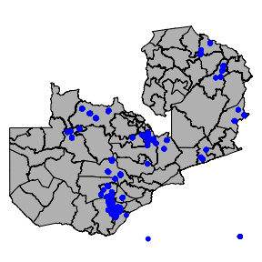

```r
par(mar = c(0, 0, 0, 0))
plot(districts, col = "grey")
lines(roads, col = "red")
points(farmers, pch = 20, col = "blue")
```

Okay, so what have we done? First, we use the `par` function with the `mar` (margin) argument and a 4-element vector of 0s to remove the inner margins of the plot so that the map of Zambia fills the plot frame. We then use `plot` to draw the map of `districts`, which are administrative boundaries for Zambia. We then use lines to add `roads` on top of that, making them red. Finally, we add the `farmers` data as blue points. Note that all these plotting functions we have used before in Unit 1 for non-spatial objects.

That’s great, you say, but I see no `roads` in the map. Where are they? And why are there two farmers outside of Zambia?

We’ll look at that in our next section.

Back to top

## 3.3 Coordinate Reference Systems and Projections

The reason you can’t see the roads on the previous map can be illustrated as follows:

```r
spdat <- list("districts" = districts,  "roads" = roads, "farmers" = farmers)
spdat_boxes <- sapply(spdat, function(x) bbox(x))
rownames(spdat_boxes) <- c("xmin", "ymin", "xmax", "ymax")
spdat_boxes
```

```
##       districts      roads  farmers
## xmin  21.999533  -292996.9  24.7769
## ymin -18.076198 -2108847.7 -18.2215
## xmax  33.705882   873238.8  33.3267
## ymax  -8.226213 -1008785.5  -8.9973
```

In the code above, I added all of our spatial datasets into a `list` (`spdat`), and then ran `sapply` over them to get the bounding boxes of each spatial object. That produced an output matrix `spdat_boxes`, to which I assigned rownames that give meaning to the bounding box values, specifically the westernmost (xmin), southernmost (ymin), easternmost (xmax), and northernmost (ymax) coordinates.

The results show us that `roads`‘coordinates are in different units (meters) than `districts`’ and `farmers`’ (both decimal degrees). That means when we try to plot `roads` on the same map as the other two, the roads don’t actually appear because the units are not the same. You can see the roads if you plot them on their own, which you should do so on your own:

Exercise 4: Plot `roads` to have a look at it (Exercise index)

We have seen this problem before with non-spatial data, specifically Task 12 in Unit 1’s assignment 3, where you were asked to plot a `loess` prediction line onto an xy scatter where “date” was the unit on the the x axis, but the loess line was calculated against an integer vector. In that case, we had to change the x values against which we were plotting `loess`, which simply meant we had to “date” into the x argument for the `lines` function to get the `loess` line to appear on the plot.

Back to top

### 3.3.1 Checking the CRS of a `Spatial*` object

In this case, we have to do a bit more, which is to convert `roads` coordinate reference system (crs) to decimal degrees. How do we do that? First, we have to know the crs we want to transform `roads` into, which we can do by checking the `proj4string` of `farmers` or `districts`. Let’s check this in two ways:

```r
districts@proj4string  # considered poor etiquette
```

```
## CRS arguments:
##  +proj=longlat +datum=WGS84 +no_defs +ellps=WGS84 +towgs84=0,0,0
```

```r
proj4string(districts)  # good etiquete
```

```
## [1] "+proj=longlat +datum=WGS84 +no_defs +ellps=WGS84 +towgs84=0,0,0"
```

The first approach uses the `@` operator, which is a method for extracting the information from a slot in an S4 object (see `?Syntax`), whereas you use the `$` operator to do the same for an S3 object. I put a comment there that suggests this is poor etiquette, because I have seen it said in places here and there over the years. The preferred method is the second one, where you are using a function designed to access and manipulate a specific slot, in this case `proj4string`.

Both approaches return the projection string, which contains the projection parameters. If you want to understand the meaning of projection string parameters, please have a look at the [documentation](http://proj4.org) for the `proj.4` library, specifically the page on [parameters](http://proj4.org/parameters.html).

This one basically tells us that `districts` has a geographic (longlat) projection, and uses the WGS84 datum. Let’s check the crs for `farmers` now to see if it has the same crs

```r
sapply(spdat[c(1, 3)], function(x) proj4string(x))
# sapply(spdat[c("districts", "farmers")], function(x) proj4string(x))
```

```
##                                                         districts
## "+proj=longlat +datum=WGS84 +no_defs +ellps=WGS84 +towgs84=0,0,0"
##                                                           farmers
##                                                                NA
```

I chose to do this programmatically in an `sapply`, in which the code demonstrates the use of recursive indexing to subset the list `spdat` (selecting the 1st and 3rd list elements, or, in the commented out alternative, doing the same with a vector of element names) and pass the subset into `sapply` (where the `proj4string` function is applied).

> An aside: In the example above, we subset a list using just a single set of brackets `[]`, not `[[]]`. You can select a single element from a list using either `[[]]` or `[]`, e.g. `spdat[1]` or `spdat[[1]]`, but you can’t select multiple elements with `[[]]`. Test it yourself using the code below.

> ```r
> l <- list(1, 2, 3)
> l[[1]]  # a vector
> l[1]  # a list
> l[[1:2]]  # fail
> l[1:2]  # a list
> ```

The results from the last `sapply` code block show that `districts` has a projection string (or p4s, as shorthand “proj4string”), whereas `farmers` does not. Before we move to the next step, reprojecting, let’s fix that.

```r
proj4string(spdat$farmers) <- proj4string(spdat$districts)
proj4string(farmers) <- proj4string(districts)
proj4string(spdat$farmers)
proj4string(farmers)
```

```
## [1] "+proj=longlat +datum=WGS84 +no_defs +ellps=WGS84 +towgs84=0,0,0"
## [1] "+proj=longlat +datum=WGS84 +no_defs +ellps=WGS84 +towgs84=0,0,0"
```

Simple–we apply the fix to `farmers` and to `spdat$farmers` by assigning the p4s from `spdat$districts` (i.e. `districts`). We can do that because we are pretty sure that the coordinates for farmers are from a geographic coordinate system that uses the WGS84 datum. If that is incorrect, we are introducing some spatial error. But for now, this is fine.

Back to top

### 3.3.2 Reprojecting with `spTransform`

Okay, so now we want to change `roads` to a GCS.

```r
spdat$roads <- spTransform(x = spdat$roads, CRSobj = proj4string(districts))
```

We use `sp`‘s `spTransform` function to reproject `spdat$roads` using the parameters supplied by `districts`’ p4s, which is passed into the function via the “CRSobj” argument.

And that’s all. We can now redo our plots. I am going to show you two ways to do it. First, the straight forward way:

```r
par(mar = c(0, 0, 0, 0))
plot(spdat$districts, col = "grey")
lines(spdat$roads, col = "red")
points(spdat$farmers, pch = 20, col = "blue")
```

[output not shown]

And a more programmatic way, since we have a list:

```r
flist <- list(plot, lines, points)
cols <- c("grey", "red", "blue")
pchs <- c(0, 0, 20)
par(mar = c(0, 0, 0, 0))
# for(i in 1:length(spdat)) flist[[i]](spdat[[i]], col = cols[i], pch = pchs[i])
for(i in 1:length(spdat)) {
  flist[[i]](spdat[[i]], col = cols[i], pch = pchs[i])
}
```

[output not shown]

The answer doesn’t relate to efficiency: I needed more lines of code in the second approach then the first (even excluded the commented out line). The purpose of this is two-fold:

First, this show that you can combine *functions* into a list and iterate through them in a `for` loop, much as we iterate through different colors and pch symbols (only `points` really needed the “pch” argument, since that is the only function plotting points in this case, but passing 0 values to the other functions doesn’t hurt).

Secondly, there is a commented out line below `par`, which is there to demonstrate an alternative syntax for running the `for` loop. If you uncomment out that line, and comment out the active `for` loop, and re-run the code, you will see it works fine. What’s more, the syntax is considered sylistically okay, since that particular line takes up less than 80 characters. If you use more than 80 characters on a line, it is better style to break the line. In the case of a `for` loop, that means going with the `{}` construction.

Okay, one more way we could have done it.

```r
adds <- c(FALSE, TRUE, TRUE)
par(mar = c(0, 0, 0, 0))
for(i in 1:length(spdat)) {
  plot(spdat[[i]], add = adds[i], col = cols[i], pch = pchs[i])
}
```

[output not shown]

Note here that I am using `plot` function, which knows whether it is plotting polygons, lines, or points based on the spatial object it is applied to. Beyond the color and pch variables (recycled from above), we have a new variable `adds`, which has the logical values `FALSE`, `TRUE`, `TRUE`. We need that because the each repeated instance of `plot` will initiate a brand new plot, unless we pass the `TRUE` into the “add” argument, which means we want to add something to the plot we just made before it.

Broken down, that looks like this:

```r
par(mar = c(0, 0, 0, 0))
plot(spdat$districts, col = "grey")
plot(spdat$roads, add = TRUE, col = "red")
plot(spdat$farmers, add = TRUE, col = "blue", pch = 20)
```

[output not shown]

Note the first plot doesn’t have the add argument, because it creates the first plot and the “add” argument has the default value of `FALSE` set. The second and third plots need us to change the “add” to `TRUE` to plot on the same line.

Right, that’s the end of this section, but you are left with a final exercise to do:

Exercise 5:

*1. Adapt the code above to reproject the spatial objects in `spdat` to the crs used by `roads`*

*2. Recreate the same plots using this newly reprojected dataset (i.e. first plot the districts then add the roads and farmers to it* (Exercise index)

Back to top

# 4 Section 2

In this section we are going to learn vector manipulations and operations, which will require the `rgeos` package.

```r
library(rgeos)
```

As you probably closed this project between Section 1 and 2, you will also need to load back in the `roads`, `districts`, and `farmers` data, and, if necessary, promote them to `Spatial*` classes. The code in Section 1 will show you how to do that.

There are a total of 6 exercises in this section:

## 4.1 Exercises

- Exercise #6
- Exercise #7
- Exercise #8
- Exercise #9
- Exercise #10
- Exercise #11

## 4.2 Extracting spatial properties

### 4.2.1 Area

Using polygons to calculate area is a fairly basic but important spatial analytical operation. To calculate meaningful areas, you typically need your polygons to be in a projected coordinate system in which area is one of the true properties. The `roads` dataset has an Albers Equal Area projection that is suitable for this purpose, so let’s apply it to reproject `districts` (as you would have done in Exercise 5, and then extract areas for each district

```r
districts_alb <- spTransform(districts, proj4string(roads))
districts_area <- gArea(spgeom = districts_alb)
districts_area  # sq meters
districts_area / 10000  # hectares
districts_area / 10^6  # km sq
```

```
## [1] 751397541695
## [1] 75139754
## [1] 751397.5
```

We apply `rgeos::gArea` to the projected `districts_alb` dataset, which returns a single value in m$^2$, or alternatively in hectares or km$^2$, with some additional calculation. But that’s for all of Zambia. What about for individual districts? For that, we simply set the “byid” argument to `TRUE`.

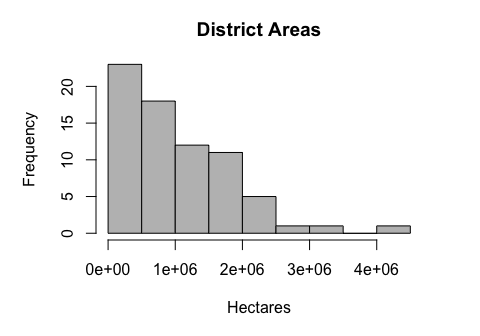

```r
district_areas <- gArea(spgeom = districts_alb, byid = TRUE)
par(mar = c(5, 5, 3, 3))
hist(district_areas / 10000, main = "District Areas", xlab = "Hectares",
     col = "grey")
```

Here we are showing the results as a histogram rather than printing out the numbers for each of the 72 districts.

There is also a second way of getting the area out of `SpatialPolygons*`, which is to access the “area” slot of each polygon. `SpatialPolygons*` objects store the area of each polygon as an attribute. The following shows how the `slot` function can be used to access the area value for the first polygon in `districts_alb`

```r
# districts_alb@polygons[[1]]@area / 1000  # get slots the non-recommended way
slot(slot(districts_alb, "polygons")[[1]], "area") / 10000  # recommended
```

```
## [1] 255152.6
```

That means we could access the area values for all 72 polygons programmatically, and then see how the areas for each polygon in the slots compare to the areas calculated using `gArea`.

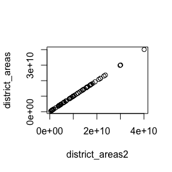

```r
district_areas2 <- sapply(1:72, function(x) {
  slot(slot(districts_alb, "polygons")[[x]], "area")
})
plot(district_areas2, district_areas)
```

See what we did there? We iterated through each polygon in `districts_alb` and extract the area slot, and then plotted the results against the `gArea`-obtained results. They look the same, but won’t necessarily always be the same. Read the “Value” section of `?gArea` to see why.

### 4.2.2 Distance

We can also calculate the distances between spatial features. To do that, we are going to make use of another `rgeos` function first, `gCentroid`, which we will use to find the coordinates of the centroid of each district, and then plot the on top of the districts themselves.

```r
dist_cent <- gCentroid(spgeom = districts_alb, byid = TRUE)  # get centroids
head(dist_cent)
```

```
## class       : SpatialPoints
## features    : 6
## extent      : -266719.8, 830861.6, -2088839, -1035133  (xmin, xmax, ymin, ymax)
## coord. ref. : +proj=aea +lat_1=20 +lat_2=-23 +lat_0=0 +lon_0=25 +x_0=0 +y_0=0 +ellps=WGS84 +units=m +no_defs
```

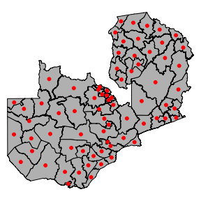

```r
# plot centroids on districts
par(mar = c(0, 0, 0, 0))
plot(districts_alb, col = "grey")
points(dist_cent, col = "red", pch = 20)
```

The resulting centroids in `dist_cent` are of class SpatialPoints. Note the use of “byid = TRUE” as an argument. If we set that to `FALSE`, or didn’t specify the argument at all, it would have returned a single set of coordinates for the centroid of Zambia. Now, here’s the first exercise for this unit:

Exercise 6: *Redo the code above so that you get just the centroid of Zambia (i.e. that single point I just mentioned), and then plot that onto the district map of Zambia (i.e. the map above, but with just one red point in Zambia’ geographic center* (Exercise index)

Moving on, we can now find out how far apart the centroids of each district are by using another `rgeos` function, `gDistance`

```r
all_dists <- gDistance(spgeom1 = dist_cent, byid = TRUE)
d1_dists <- gDistance(spgeom1 = dist_cent[1, ], spgeom2 = dist_cent[-1, ],
                      byid = TRUE)
quantile(d1_dists / 1000)
```

```
##         0%        25%        50%        75%       100%
##   60.72644  438.68514  533.74313  685.22578 1057.38108
```

There are two variants above. The first is captured in `all_dists`, and it produces a matrix that provides the distance, in meters, between each district centroid and every other district centroid. To get that, you simply pass in the entire `dist_cent` object to the “spgeom1” argument, and specify “byid = TRUE”. The second variant (`d1_dists`), uses both “spgeom1” and “spgeom2” arguments, and it simply finds the distance between the first district centroid and all the other districts’ centroids.

I invite you to examine the contents of both of those objects–I am not printing them here because this vignette is already long. What I do show you is a summary of the distances in kilometers using the `quantile` function.

Okay, here’s another exercise:

[Exercise 7] *Figure out which district is the closest to the centroid of Zambia, and how far that distance is in kilometers* (Exercise index)

### 4.2.3 Length

For the last example of functions that extract spatial properties, we will use `gLength` to calculate line lengths.

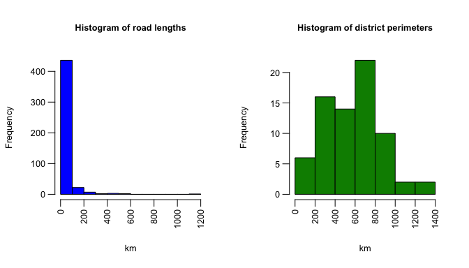

```r
road_lengths <- gLength(spgeom = roads, byid = TRUE)
district_perims <- gLength(spgeom = districts_alb, byid = TRUE)

par(mfrow = c(1, 2), mgp = c(3, 0.7, 0))
hist(road_lengths / 1000, xlab = "km", col = "blue", las = 2, cex.main = 0.8,
     cex.lab = 0.8, cex.axis = 0.8, main = "Histogram of road lengths")
hist(district_perims / 1000, xlab = "km", col = "green4", las = 2,
     cex.main = 0.8, cex.lab = 0.8, cex.axis = 0.8,
     main = "Histogram of district perimeters")
```

`gLength` applied to `SpatialLines*` gives us line lengths, and for `SpatialPolygons` it gives us perimeter length (including the perimeter around any holes in the polygons). If “byid = FALSE” (the default) in either case, you get total length (of all line segments or of all polygon perimeters).

The histograms plotted above have some graphical parameters added to them that might be new to you (“mgp”, “cex.main”, “cex.lab”, “cex.axis”).

[Exercise 8] *Rerun those plots, changing the values (at least one time), to the “mgp”, “cex.main”, “cex.lab”, and “cex.axis” arguments.* (Exercise index)

Back to top

## 4.3 Manipulating `Spatial*DataFrames`

`Spatial*` objects in R can be manipulated using fairly similar methods as those used for manipulating non-spatial data structures. The code in the previous sections provides examples for how you subset by index numbers. Another example:

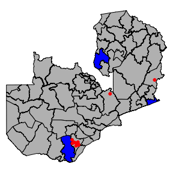

```r
par(mar = c(0, 0, 0, 0))
plot(districts_alb, col = "grey")
plot(districts_alb[c(1, 20, 40), ], col = "blue", add = TRUE)
points(spTransform(farmers, proj4string(roads))[30:40, ], col = "red", pch = 20)
```

Notice that the sub-setting is done “on the fly” within the plotting functions themselves. The one applied to farmers follows the necessary reprojection step, which is also done on the fly.

That’s index-based subsetting. We can also do it using values stored within the rows and columns of the data. But to do that, we are first going to enhance those data a bit.

Back to top

### 4.3.1 Merges

The previous examples have shown you how to calculate spatial properties and stick them in separate data objects. Now let’s see how to add those properties to our `Spatial*DataFrame`s.

We’ll continue working with `districts_alb`, and start by adding the district areas to the `data.frame` of `districts_alb2`, a copy of `districts_alb`

```r
districts_alb2 <- districts_alb  # create a new version
districts_alb2$area <- gArea(districts_alb2, byid = TRUE)
# head(districts_alb@data)
head(slot(districts_alb2, "data"))
```

```
##        distName        area
## 0       Chadiza  2551526279
## 1         Chama 17400862112
## 2       Chavuma  4595221399
## 3      Chibombo 13436140335
## 4       Chiengi  3765253403
## 5 Chililabombwe   997467336
```

So that’s a fairly straightforward way to do it. Just append the areas as a new column name on `districts_alb2` (which we create), which exactly the same way you would do it if this was just an ordinary `data.frame`. Note that this change only affects the `data.frame` part of `districts_alb`, and that to view the altered data.frame, you have to extract the `data.frame` from its slot.

We could also do the same thing this way:

```r
districts_alb2 <- cbind(districts_alb,
                        gArea(districts_alb, byid = TRUE))
colnames(districts_alb2@data) <- c("distName", "area")
head(slot(districts_alb2, "data"))
```

```
##        distName        area
## 0       Chadiza  2551526279
## 1         Chama 17400862112
## 2       Chavuma  4595221399
## 3      Chibombo 13436140335
## 4       Chiengi  3765253403
## 5 Chililabombwe   997467336
```

Or this way

```r
dist_area_df <- data.frame("distName" = districts_alb$distName,
                           "area" = gArea(districts_alb, byid = TRUE))
districts_alb2 <- merge(districts_alb, dist_area_df, by.x = "distName",
                        by.y = "distName")
head(slot(districts_alb2, "data"))
```

```
##        distName        area
## 1       Chadiza  2551526279
## 2         Chama 17400862112
## 3       Chavuma  4595221399
## 4      Chibombo 13436140335
## 5       Chiengi  3765253403
## 6 Chililabombwe   997467336
```

This last one might be new to you, as it uses the `merge` function. We had it in earlier readings, but didn’t go over it much in class. `merge` basically joins two `data.frame`s by the values in one or more columns that share the same values, or subsets of the same values. There is a `merge` method for ordinary `data.frame`s, and, as we see here, one for `Spatial*DataFrame`s.

That brings us to our next exercise, for which I will first do some more work to help:

```r
roads$roadnum <- 1:length(roads)  # new identifier, because of NAs in "roadid"
```

Exercise 9: *Adapt the code you see above to calculate road lengths (in km) in `roads`, and merge the resulting `data.frame` containing the road lengths and “roadnum” identifier (the merge key) onto `roads`, to create a new `roads2` object. Plot the histogram of those lengths, making the bars blue* (Exercise index)

Back to top

### 4.3.2 Subsetting

Now that we have upgraded the `data.frame` in `districts_alb2`, we can do some more subsetting.

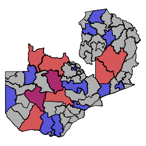

```r
dists_begkn <- districts_alb2[grep("^Ka|^Nyi", districts_alb2$distName), ]
dists_gt2M <- districts_alb2[districts_alb2$area / 10000 > 2000000, ]

par(mar = c(0, 0, 0, 0))
plot(districts_alb2, col = "grey")
plot(dists_begkn, col = rgb(0, 0, 1, alpha = 0.5), add = TRUE)
plot(dists_gt2M, col = rgb(1, 0, 0, alpha = 0.5), add = TRUE)
```

That’s two examples of subsetting, in which the first (`dists_begkn`) selects districts with names beginning with either “Ka” or “Nyi”, and the second (`dists_gt2M`) selects districts having areas greater than 2 million hectares (notice the division by 10000 to convert from m$^2$ to ha).

The resulting subsets are plotted onto the full district map of Zambia. Note the use of the `rgb` function to define the colors used to fill the polygons. `rgb` makes red-green-blue color combinations, and the alpha argument allows you to define the transparency of the color. In this case, our two subsets selected some of the same polygons (two of the districts with names beginning with “Ka” or “Ny” are also large than 2 million ha), so the partial transparency allows us to show where the overlaps occur.

As an exercise, create new district subsets by use a different grep pattern match on the district names (look at `districts_alb2$distName` for some ideas), and by changing the area used as a threshold (e.g. make it 1 million ha) size, and the replot the results. This leads us to our penultimate exercise for this section, which should be fairly easy (you will probably just have to read `?rgb` to figure it out)

Back to top

### 4.3.3 Split-apply-combine

As with plain old `data.frame`s, we might want to do split-apply-combine operations on spatial data. Let’s demonstrate this selecting the districts in `districts_alb2` that fall within certain area ranges, convert the selected districts to centroid points, and then plot them.

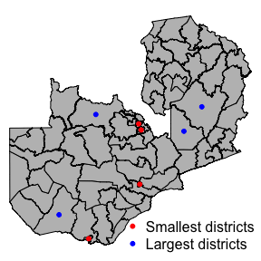

```r
# define area ranges for smallest and largest districts
qt1090 <- quantile(districts_alb2$area, c(0.0, 0.05, 0.95, 1))
qt1090 <- rbind(qt1090[1:2], qt1090[3:4])

# split-apply-combine
smlg_dist <- lapply(1:nrow(qt1090), function(x) {
  dists <- districts_alb2[districts_alb2$area >= qt1090[x, 1] &
                            districts_alb2$area <= qt1090[x, 2], ]
  gCentroid(dists, byid = TRUE)
})

# plot, with legend
cols <- c("red", "blue")
par(mar = c(0, 0, 0, 0))
plot(districts_alb2, col = "grey")  # map background
for(i in 1:length(smlg_dist)) {
  points(smlg_dist[[i]], col = cols[i], pch = 20)
}
legend(x = "bottomright", pch = 20, col = cols, bty = "n",
       legend = c("Smallest districts", "Largest districts"))
```

That’s pretty busy, so let me explain:

- The first two lines use the `quantile` function to select the ranges of district areas within which the smallest 5% of districts and largest 5% of districts lie. It places these ranges within a matrix `qt1090`, where row 1 contains the minimum (column 1) and maximum (column 2) areas bounding the smallest 5% of areas, and row 2 does the same for the largest 5%.
- The second block runs a split-apply-combine with `lapply`. The iteration occurs over the rows of `qt1090`, and the *split* is done by selecting the districts `districts_alb2` containing areas that fall within the ranges defined by the area values in the selected row of `qt1090`. `gCentroid` is then *applied* to the selected districts, which are combined into list `smlg_dist`.
- The plot first sets up a base map of all the districts, then loops over `smlg_dist` and plots each set of points with a different color. New to this plot is the `legend` function.

Okay, now for our final exercise of this section:

Exercise 11: *Taking the split-apply-combine code above as an example, find*

*1. The 15th, 25th and 75th, and 85th percentile area value for districts*

*2. Apply the split apply combine, selecting districts falling between the 15th and 25th percentiles of area, and between the 75th and 85th percentile areas, calculating the centroids of the selected districts*

*3. Plot the centroids as above* (Exercise index)

Back to top

# 5 Section 3

In this section we will start to do some spatial operations (overlays/extractions, intersections, unions, and differences), and also learn how to create polygons from scratch. We are going start working with the `raster` package as well, which seems strange given that we are working with vectors, but the reason why will become clear below.

## 5.1 Exercises

- Exercise #12
- Exercise #13
- Exercise #14
- Exercise #15

## 5.2 Spatial Operations

Now we will move onto some of the common spatial operations that you can expect to do with polygons. To enable this, we are first going to create some additional spatial data.

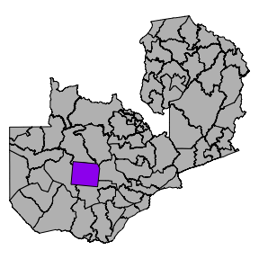

```r
# define data.frame of arbitrary x and y coordinates
coords <- data.frame("x" = c(25, 25.1, 26.3, 26.4, 26.3, 25.1),
                     "y" = c(-15.5, -14.5, -14.6, -14.8, -15.6, -15.5))

# create SpatialPolygons
p <- Polygon(coords = coords)
ps <- Polygons(srl = list(p), ID = 1)
spp <- SpatialPolygons(Srl = list(ps))

# define GCS projection and transform to Albers
proj4string(spp) <- proj4string(districts)
spp_alb <- spTransform(spp, proj4string(roads))
spp_alb <- SpatialPolygonsDataFrame(spp_alb, data.frame("ID" = 1))

par(mar = rep(0, 4))
plot(districts_alb2, col = "grey")
plot(spp_alb, col = "purple", add = TRUE)
```

The above takes a `data.frame` of x and y coordinates, and builds it up through three steps into `SpatialPolygons`. Step 1 creates a single polygon `p` from the coordinates, step 2 combines that polygon into a polygon list with an ID value, and step3 turns the list of the list into `SpatialPolygons` (`spp`). We then define its crs and reproject it to Albers so we can plot out onto the map of Zambian districts.

Back to top

### 5.2.1 Overlays/spatial queries

The first thing we will do with our made-up polygon is figure out which districts it intersects. What we are going to do in this case is the ArcGIS equivalent of select by spatial location (I hope I am remembering my ESRI terminology correctly–it’s been a while since I looked at it)

```r
spp_alb_int <- over(x = spp_alb, y = districts_alb2, returnList = TRUE)
spp_alb_int
```

```
## [[1]]
##        distName        area
## 15 Itezhi Tezhi 15709159125
## 22        Kaoma 22989102895
## 26      Kasempa 21502361506
## 53     Mufumbwe 19237709093
## 54       Mumbwa 21491901285
```

The `over` function returns the subset of `districts_alb2` that `spp_alb` overlies, returning the relevant subset of `districts_alb2`’s data.frame within a list. What `over` does, from `?sp::over`:

> consistent spatial overlay for points, grids and polygons: at the spatial locations of object x retrieves the indexes or attributes from spatial object y

Another way of figuring out the same answer is with an `rgeos` function, `gIntersects`

```r
spp_alb_int <- gIntersects(spgeom1 = spp_alb, spgeom2 = districts_alb2,
                           byid = TRUE)
head(spp_alb_int)
```

```
##       1
## 0 FALSE
## 1 FALSE
## 2 FALSE
## 3 FALSE
## 4 FALSE
## 5 FALSE
```

```r
which(spp_alb_int)
```

[output not shown]

So that gives somewhat different results. First, `gIntersects` returns a logical value, giving a `TRUE` or `FALSE` for each district in `districts_alb2` as to whether it is intersected by `spp_alb`. We can use the `which` operator to identify the index of the intersecting districts, and then use the indices to subset out the matching districts, as follows.

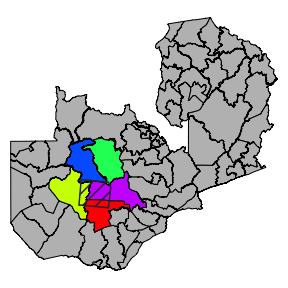

```r
spp_alb_int <- which(gIntersects(spgeom1 = spp_alb, spgeom2 = districts_alb2,
                                 byid = TRUE))
districts_int_spp <- districts_alb2[spp_alb_int, ]

par(mar = c(0, 0, 0, 0))
plot(districts_alb2, col = "grey")
plot(districts_int_spp, add = TRUE,
     col = rainbow(n = length(districts_int_spp)))
plot(spp_alb, add = TRUE, border = "grey20", col = "grey20", density = 10,
     angle = 45, lwd = 1.5)
```

In the code above, you will see that we slightly revised the code, by putting the `gIntersects` inside the `which` function, and capturing the output in `spp_alb_int`, which we then used to subset `districts_alb2` into a new object: `districts_int_spp`.

In the plot commands function, you will also see a new way of selecting colors, using the `rainbow` function. In this case, we tell `rainbow` to select “n” colors (here equal to the number of districts in `districts_int_spp`), giving us a different color for each of the selected districts. We also overlay `spp_alb` onto the districts it intersects, using angled cross-hatching in place of a fill color (set using the “density” and “angle” arguments). Cross-hatching is apparently considered a no-no by visualization experts, however, because it can produce perception distortions, but now you know how to do it.

Back to top

### 5.2.2 Intersections

We have just seen how `gIntersects` can be used to identify intersecting polygons. Now let’s look at what `gIntersection` does.

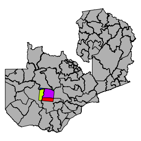

```r
spp_int_distrs <- gIntersection(spgeom1 = spp_alb, spgeom2 = districts_alb2,
                                byid = TRUE)

par(mar = rep(0, 4))
plot(districts_alb2, col = "grey")
plot(spp_int_distrs, col = rainbow(n = length(spp_int_distrs)), add = TRUE)
```

Seems pretty clear what `gIntersection` does, and how it differs from `gIntersects`. However, note that you have to use the “byid = TRUE” option if you want to retain the detail of the intersected district boundaries, else you would get this:

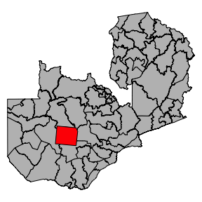

```r
spp_int_distrs <- gIntersection(spgeom1 = spp_alb, spgeom2 = districts_alb2)

par(mar = rep(0, 4))
plot(districts_alb2, col = "grey")
plot(spp_int_distrs, col = rainbow(n = length(spp_int_distrs)), add = TRUE)
```

Just a single filled polygon, not what we were hoping to see.

Here’s a much friendlier way of doing an intersection, using (somewhat counterintuitively) a function from the `raster` package. The developers of the `raster` package have created a more user friendly set of certain `rgeos` functions, so we are going to demonstrate those here, in contrast to the `gIntersection`

```r
library(raster)
spp_int_distrs <- gIntersection(spgeom1 = spp_alb, spgeom2 = districts_alb2,
                                byid = TRUE)
spp_int_distrs2 <- intersect(x = spp_alb, y = districts_alb2)
class(spp_int_distrs2)[1]
```

```
## [1] "SpatialPolygonsDataFrame"
```

```r
class(spp_int_distrs)[1]
```

```
## [1] "SpatialPolygons"
```

It turns out that `raster` has a function (`intersect`) that does the same job as `rgeos` (go ahead and plot `spp_int_distrs2`, and you will see) but even better, as it retains the relevant information from any `data.frame`(s) in the objects being intersected; `gIntersection` only returns the intersected geometries, and you need to do a great deal more work to recover and then join the accompanying attributes to the geometries.

> An aside: These last example demonstrates both a strength and weakness of R, in my opinion–R’s strength is that you can usually find multiple solutions to solve a particular problem; R’s weakness is that choosing the best solution can be tricky, given the profusion of choice, and you might end up trying something that takes up a lot of your time.

> ```r
> detach("package:raster", unload = TRUE)
> farmers[1:2, ]
> ```

> ```
> ## An object of class "SpatialPointsDataFrame"
> ## Slot "data":
> ##       uuid       date pl ra
> ## 1 009a8424 2016-10-31 NA  0
> ## 2 00df166f 2016-10-31 NA  0
> ##
> ## Slot "coords.nrs":
> ## [1] 3 2
> ##
> ## Slot "coords":
> ##       lon      lat
> ## 1 27.2559 -16.9257
> ## 2 26.9425 -16.5036
> ##
> ## Slot "bbox":
> ##          min      max
> ## lon  26.9425  27.2559
> ## lat -16.9257 -16.5036
> ##
> ## Slot "proj4string":
> ## CRS arguments:
> ##  +proj=longlat +datum=WGS84 +no_defs +ellps=WGS84 +towgs84=0,0,0
> ```

> ```r
> library(raster)
> farmers[1:2, ]
> ```

> ```
> ## class       : SpatialPointsDataFrame
> ## features    : 2
> ## extent      : 26.9425, 27.2559, -16.9257, -16.5036  (xmin, xmax, ymin, ymax)
> ## coord. ref. : +proj=longlat +datum=WGS84 +no_defs +ellps=WGS84 +towgs84=0,0,0
> ## variables   : 4
> ## names       :     uuid,       date, pl, ra
> ## min values  : 009a8424, 2016-10-31, NA,  0
> ## max values  : 00df166f, 2016-10-31, NA,  0
> ```

> And the code above demonstrates more package differences. Detaching/unloading `raster`, as done above, and then printing out farmers (just the first two lines, to avoid a very long print of all coordinates) provides a much more longer and less convenient output (produced by `sp`) than the one produced by the `raster` package after it is re-loaded.

### 5.2.3 Aggregation/Dissolve

Now that we have intersected boundaries, let’s dissolve them.

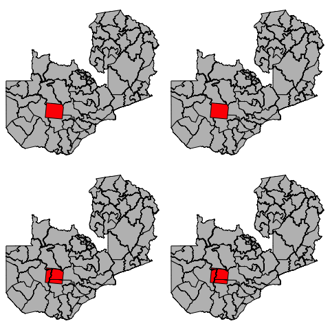

```r
spintd_agg <- aggregate(x = spp_int_distrs2, by = "ID")
spintd_agg2 <- aggregate(x = spp_int_distrs2)
spintd_agg3 <- aggregate(x = spp_int_distrs2, dissolve = FALSE)
spintd_agg4 <- aggregate(x = spp_int_distrs2, by = "ID", dissolve = FALSE)

l <- list(spintd_agg, spintd_agg2, spintd_agg3, spintd_agg4)
par(mfrow = c(2, 2), mar = c(0, 0, 0, 0))
for(i in l) {
  plot(districts_alb2, col = "grey")
  plot(i, col = rainbow(n = length(i)), add = TRUE)
}
```

> Function note: There are two versions of `aggregate` that we could have used here. The `raster` package has its own version, which is simpler than the one provided by `sp`. Since we loaded `raster` last into our environment (remember how to confirm that? use `search()` to check the load order), the version we are using here is the one provided by `raster`, which works on rasters as well as `SpatialPolygons`.

```r
sapply(l, class)
```

```
## [1] "SpatialPolygonsDataFrame" "SpatialPolygons"
## [3] "SpatialPolygons"          "SpatialPolygonsDataFrame"
```

```r
t(sapply(l, function(x) {
  c("N poly groups" = length(x),  # 1
    "N polys in group" = length(slot(slot(x, "polygons")[[1]], "Polygons"))) # 2
}))
```

```
##      N poly groups N polys in group
## [1,]             1                1
## [2,]             1                1
## [3,]             1                6
## [4,]             1                6
```

> Code explanation: The somewhat complex bit of code above uses `sapply` to loop through each permutation of the aggregations, and first line in the body (# 1) queries how many polygons groups each element of `l` has, while the second line (# 2) does this:
> - `slot(x, "polygons")[[1]]` grabs the first group of polygons (there is only one in this example) living under the “polygons” slot of the `SpatialPolygonsDataFrame` `x` (anyone of the four aggregated objects in `l`). There is only one “polygons” slot in any `SpatialPolygonsDataFrame`.
> - `slot(<snip>, "Polygons")` accesses the “Polygons” slot from the first group of polygons (which was extracted as described above, the code for which fits into the place where is now). There can be multiple polygons living in each polygon group, one or more of which may define holes in another polygon(s) in the group, or which many simply be polygons representing parts of a more complicated thing that is considered a *single feature*, such as an island chain that has one name (e.g. the State of Hawaii, or Indonesia).
> - That is why there is this awkward and complicated structure to `SpatialPolygons*`

What does the output of that `sapply` tell us? That each of objects in `l` has just one polygon group, and that for the first two objects there only have one polygon per polygon group. The reason for that is that the aggregation *dissolved* the district boundaries. The second two were aggregated differently–they were not dissolved, but instead aggregated so that the polygons are now gathered into a single polygon group that is taken to represent the components of a single feature (as described above).

Now, for some more advanced coding. The `sapply` above is somewhat half-baked, because it assumes that the `SpatialPolygons*` in `l` only have one polygon group each. Here is how we would make that query more programmatic, i.e. if we didn’t want to assume there was only one polygon group per object in `l`:

```r
# x <- 1
# y <- 1
do.call(rbind, lapply(1:length(l), function(x) {
  p <- slot(l[[x]], "polygons")  # get polygons slot from l[[x]]
  ps <- t(sapply(1:length(p), function(y) {  # loop through p's poly groups
    a <- length(slot(p[[y]], "Polygons"))  # find out # polys in each poly group
    c("poly group" = y, "N polys in group" = a) # combine w/ y, poly grp counter
  }))  # transpose sapply results to get variables as columns
  cbind("object#" = x, ps)  # cbind x with ps, giving a label for object
}))
```

```
##      object# poly group N polys in group
## [1,]       1          1                1
## [2,]       2          1                1
## [3,]       3          1                6
## [4,]       4          1                6
```

I am not going to explain this code too much, but what it does is give you a way of creating the same result as the previous `sapply`, plus some information about which object in the list corresponds to the results. If you run the two commented out lines above the code, you can use that to step through the inner parts of the function, which is more complex than you have seen before because it nests `sapply` (wrapped in `t`) within an `lapply`. That will help you understand the code better.

However, the main point of showing that code is so that you can recycle it for an exercise:

Exercise 12: *Recreate the list `l` so that it contains just two objects: `spp_int_distrs2` and `spintd_agg4`. Rerun the code directly above with the new `l`. What do the results tell us about the structures of the two objects in `l`?* Exercise index

By the way, before we go into the next section, just wanted to mention that the `gUnaryUnion` dissolves the same way that `aggregate` does by default (e.g. as done to make `spintd_agg2` above), producing just `SpatialPolygons` output.

```r
gUnaryUnion(spgeom = spp_int_distrs2)
```

```
## class       : SpatialPolygons
## features    : 1
## extent      : 0, 144085.8, -1837154, -1709941  (xmin, xmax, ymin, ymax)
## coord. ref. : +proj=aea +lat_1=20 +lat_2=-23 +lat_0=0 +lon_0=25 +x_0=0 +y_0=0 +ellps=WGS84 +units=m +no_defs
```

```r
spintd_agg2
```

```
## class       : SpatialPolygons
## features    : 1
## extent      : 0, 144085.8, -1837154, -1709941  (xmin, xmax, ymin, ymax)
## coord. ref. : +proj=aea +lat_1=20 +lat_2=-23 +lat_0=0 +lon_0=25 +x_0=0 +y_0=0 +ellps=WGS84 +units=m +no_defs
```

### 5.2.4 Disaggregation

We have shown how you can aggregate `SpatialPolygons*`. Now let’s see about disaggregating polygons that have been aggregated.

```r
spintd_dagg <- disaggregate(x = spintd_agg)
spintd_dagg4 <- disaggregate(x = spintd_agg4)

l <- list(spintd_dagg, spintd_dagg4, spintd_agg4)
sppoly_structure(l)
```

```
##      object# poly group N polys in group
## [1,]       1          1                1
## [2,]       2          1                1
## [3,]       2          2                1
## [4,]       2          3                1
## [5,]       2          4                1
## [6,]       2          5                1
## [7,]       2          6                1
## [8,]       3          1                6
```

```r
?sppoly_structure
```

```
## Using development documentation for sppoly_structure
```

In the above, we have applied `disaggregate` to the dissolved aggregate `spint_agg`, and to the version of the aggregation in which the districts were aggregated into a single polygon group (`spintd_agg4`). We combine the results of the two disaggregation into a list, together with `spintd_agg4`, and then run `sppoly_structure` on it.

> Wait, what is `sppoly_structure`? That complicated thing I asked you to run for Exercise 12–I added it as a function to the `geospaar` package so that I didn’t have to keep copying a big chunk of code that I want to use–that right there (the need to repeatedly reuse some code) is the main reason for writing and documenting a package function. Have a look at `?sppoly_function`.

The results tell us that you can’t really disaggregate `SpatialPolygons*` that have been dissolved, but you can split up a polygon group containing multiple polygons into multiple polygon groups, each with a single polygon in it. Compare the results for object#s 2 (`spintd_dagg4`) and (`spintd_dagg4`) 3 in the output from `sppoly_structure` above to see how disaggregation changes the structure of an aggregated polygon.

Back to top

### 5.2.5 Differences

The two preceeding sections gave a rather long look at aggregation/disaggregation and how to query slots. The intention there was to better explore the fairly complicated structures of `SpatialPolygons*`, and how slots are queried. Please ask questions in class if this stuff doesn’t make sense.

Now we are going to move on to do look at another bread and butter operation, differencing (or erasing).

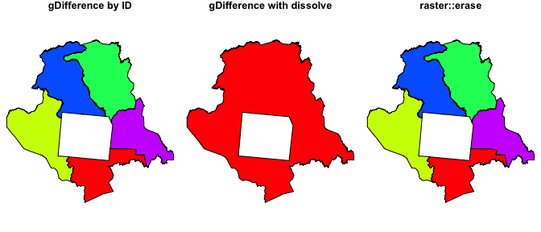

```r
d1a <- gDifference(spgeom1 = districts_int_spp, spgeom2 = spp_alb, byid = TRUE)
d1b <- gDifference(spgeom1 = districts_int_spp, spgeom2 = spp_alb)
d2 <- erase(x = as(districts_int_spp, "SpatialPolygons"),
            y = as(spp_alb, "SpatialPolygons"))

l <- list(d1a, d1b, d2)
titles <- c("gDifference by ID", "gDifference with dissolve", "raster::erase")
par(mfrow = c(1, 3), mar = c(0, 0, 1, 0))
for(i in 1:length(l)) {
  plot(l[[i]], col = rainbow(n = length(l[[i]])), main = titles[i])
}
```

That shows `rgeos::gDifference` applied two ways to cut out the area of `spp_alb` from the districts it *intersects*, one in which the remainder shape of each district is preserved (with the “byid = TRUE” argument), the other in which the remainders of the districts are dissolved. The function `raster::erase` does the same as the first version of `gDifference`. In this case, we coerce the two input objects to `SpatialPolygons` to deal with an error `erase` was throwing about row.names in the `data.frame` not matching the polygons IDs.

Exercise 13: *Run the `erase` example again, but apply it to the `districts_int_spp` and `spp_alb` without coercing them to `SpatialPolygons` to see the error. How do you think we could fix those errors? No need to do it, but just want you to think how you might do it. Hints: look at the function `spChFids` and at Kristen’s solution in this [post](https://groups.google.com/forum/#!topic/davis-rug/BmchhejJm4M)* Exercise index

> Plotting tip: note in the code above how we add titles to the plots, and also tweak the margins to add space to the top margin so that those titles can be displayed.

Back to top

### 5.2.6 Unions

We have already seen a `gUnaryUnion`, which is basically a dissolve. Now let’s look at unions in the way you are probably more used to seeing them in traditional GIS.

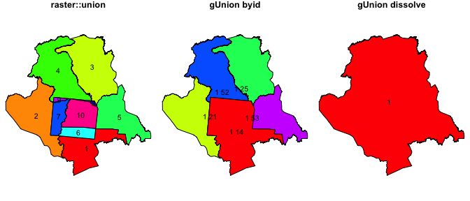

```r
spp_dist_uni1 <- union(x = spp_alb, y = districts_int_spp)
spp_dist_uni2 <- gUnion(spgeom1 = spp_alb, spgeom2 = districts_int_spp,
                        byid = TRUE)
spp_dist_uni3 <- gUnion(spgeom1 = spp_alb, spgeom2 = districts_int_spp)

l <- list(spp_dist_uni1, spp_dist_uni2, spp_dist_uni3)
titles <- c("raster::union", "gUnion byid", "gUnion dissolve")
par(mfrow = c(1, 3), mar = c(0, 0, 1, 0))
for(i in 1:length(l)) {
  dlabs <- sapply(slot(l[[i]], "polygons"), function(x) slot(x, "ID"))
  plot(l[[i]], col = rainbow(n = length(l[[i]])), main = titles[i])
  text(l[[i]], labels = dlabs)
}
```

```r
sapply(l, class)
```

```
## [1] "SpatialPolygonsDataFrame" "SpatialPolygons"
## [3] "SpatialPolygons"
```

```r
slot(l[[1]], "data")
```

```
##        distName        area ID
## 1  Itezhi Tezhi 15709159125 NA
## 2         Kaoma 22989102895 NA
## 3       Kasempa 21502361506 NA
## 4      Mufumbwe 19237709093 NA
## 5        Mumbwa 21491901285 NA
## 6  Itezhi Tezhi 15709159125  1
## 7         Kaoma 22989102895  1
## 8       Kasempa 21502361506  1
## 9      Mufumbwe 19237709093  1
## 10       Mumbwa 21491901285  1
```

Three different ways of doing a union, the first with raster::union, which as the `?union` for it describes, does this when applied to SpatialPolygons*:

> Overlapping polygons (between layers, not within layers) are intersected, other spatial objects are appended. Tabular attributes are joined.

You can see how `union` joins the attributes above.

The other two ways are with `gUnion`, which allows unioning by ID (middle map), or a complete dissolve. As with the earlier `rgeos` functions, the operation leaves behind attributes. And you will see that the union-by-id result looks rather different than the one produced by `raster`, seeming to dissolve `spp_alb` into the entirety of one districts but only the overlapping parts of the other districts. Keep these alternative behaviors in mind when selecting a function.

> Plotting notes: In the plots we just made above, we use the `slot` function to grab the polygon IDs from each of the unioned `SpatialPolygons*`, and then use the `text` function, in this case a `generic` method from the `raster` package (there are other method for plotting text into other kinds of plots, e.g. xy scatter plots), to label the polygons in the map with the polygon labels. The visualization helps to understand some differences in the various unioning methods.

Back to top

### 5.2.7 Buffering

A fairly common operation

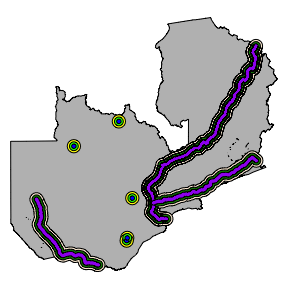

```r
# Block 1
farmers_alb <- spTransform(farmers, proj4string(roads))  # 1
long_roads <- roads[which(road_lengths > 500000), ]  # 2

# Block 2
bwidths <- c(10000, 20000, 30000) # 1
set.seed(1) # 2
n <- sample(1:nrow(farmers_alb), size = 5, replace = TRUE)  # 3

# Block 3
buffs <- lapply(bwidths, function(x) {  # 1
  fbuf <- buffer(x = farmers_alb[n, ], width = x, dissolve = FALSE)  # 2
  rbuf <- buffer(x = long_roads, width = x, dissolve = FALSE)  # 3
  list("farm" = fbuf, "road" = rbuf)  # 4
})  # 5

# Block 4
par(mar = c(0, 0, 0, 0))  # 1
cols <- c("blue", "green", "yellow")  # 2
cols2 <- c("purple", "green4", "antiquewhite")
plot(aggregate(districts_alb2, dissolve = TRUE), col = "grey")  # 3
for(i in length(buffs):1) {  # 4
  plot(buffs[[i]]$farm, add = TRUE, col = cols[i])  # 5
  plot(buffs[[i]]$road, add = TRUE, col = cols2[i])  # 6
}
```

There is a lot of code above, but I am not going to explain it this time. Rather, I am going to give you two exercises to do with it:

Exercise 14: *Explain what each of the 4 code blocks is doing, line by line. The buffering operation is happening in one of them. We will go over this in class.*

Exercise 15: *Re-run the code above, except you should first replace the buffering function used above with the `gBuffer` function from rgeos. And then, once you have done that, run it again, but this time allow the buffering function to dissolve buffers where they intersect (either buffer approach will do that, so use the one you like best)* Exercise index

# 6 Unit Summary

This unit section has given a brief and by no means exhaustive introduction to do some common vector operations and ways in which vector data are manipulated. Along the way, it has also introduced some new plotting approaches and vocabulary, and has explored some of the issues regarding SpatialPolygons* structuring.

There are a number of other types of operations that we could have looked at, some or many of which we will undoubtedly encounter as we plunge ahead.